# Peer Assessment 1

mt

Saturday, september 19, 2015

## Introduction

Activity recognition consists of broad range of application in security systems, gaming platforms, health care systems and etc. The first step in the case of working with evaluated datasets is changing raw data into prcessed data. Removing Not Assigned values and changing the name of columns in this dataset is the prerequisite of processed data.

This assignment makes use of data from a personal activity monitoring device. This device collects data at 5 minute intervals through out the day. The data consists of two months of data from an anonymous individual collected during the months of October and November, 2012 and include the number of steps taken in 5 minute intervals each day

## Loading and preprocessing the data

the dataset could download from here:

https://d396qusza40orc.cloudfront.net/repdata%2Fdata%2Factivity.zip

#### 1- Load the data (i.e. read.csv())

```r
setwd(file.path("D:", "sbu", "RLearning", "reproducible research","programming1"))
activity <- read.csv("activity.csv")
head(activity,4)
```

```
##   steps       date interval
## 1    NA 2012-10-01        0
## 2    NA 2012-10-01        5
## 3    NA 2012-10-01       10
## 4    NA 2012-10-01       15
```

#### 2- Process/transform the data (if necessary) into a format suitable for your analysis

```r
library(dplyr)
Ractivity <-tbl_df(activity)
rm(activity)
```

## What is mean total number of steps taken per day?

## For this part of the assignment, you can ignore the missing values in the dataset.

#### 1- Calculate the total number of steps taken per day

```r
by_date<-group_by(Ractivity[!is.na(Ractivity$steps),],date)
total_steps<-summarize(by_date, TotalStepsPerDay=sum(steps))
head(total_steps,7)
```

```
## Source: local data frame [7 x 2]
##
##         date TotalStepsPerDay
## 1 2012-10-02              126
## 2 2012-10-03            11352
## 3 2012-10-04            12116
## 4 2012-10-05            13294
## 5 2012-10-06            15420
## 6 2012-10-07            11015
## 7 2012-10-09            12811
```

#### 2- If you do not understand the difference between a histogram and a barplot, research the difference between them.

#### Make a histogram of the total number of steps taken each day.

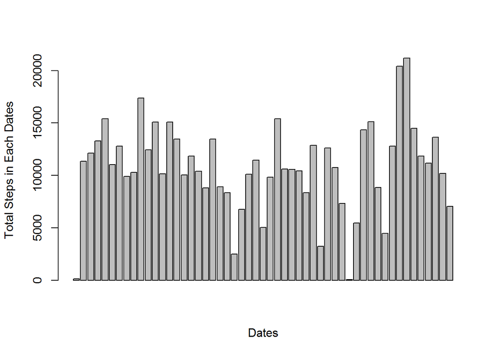

```r
barplot(total_steps$TotalStepsPerDay,xlab="Dates",ylab="Total Steps in Each Dates")
```

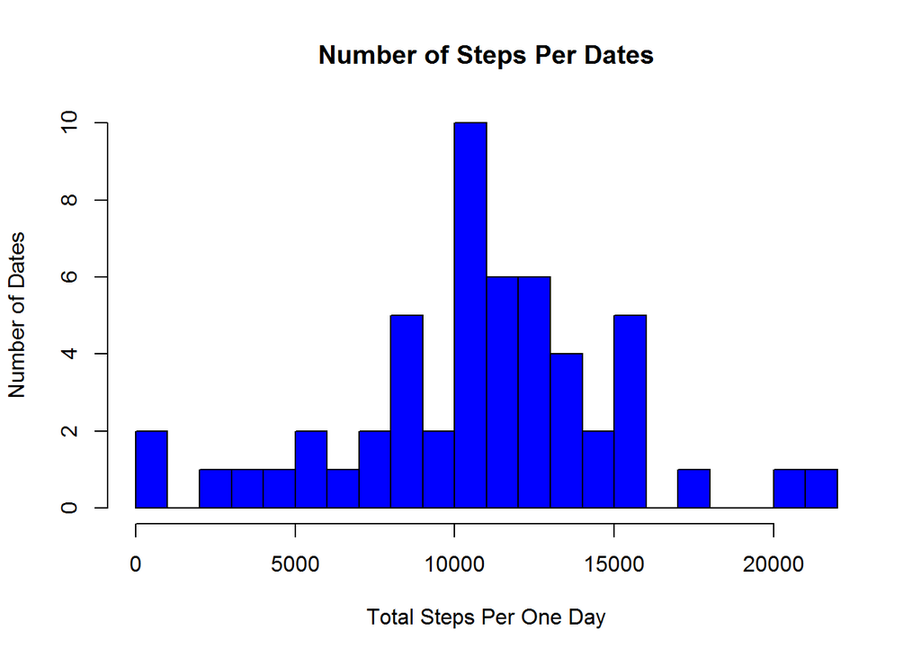

```r
hist(total_steps$TotalStepsPerDay,30,col = "blue",
xlab="Total Steps Per One Day",ylab="Number of Dates",main="Number of Steps Per Dates")
```

- In BarPlot each dates has its own frequency where Histogram shows number of dates with close frequency.

```r
MeanMedianSteps<-summarize(by_date,MeanStepsPerDay=mean(steps),
                           MedianStepsPerDay=median(steps))
head(MeanMedianSteps,6)
```

```
## Source: local data frame [6 x 3]
##
##         date MeanStepsPerDay MedianStepsPerDay
## 1 2012-10-02         0.43750                 0
## 2 2012-10-03        39.41667                 0
## 3 2012-10-04        42.06944                 0
## 4 2012-10-05        46.15972                 0
## 5 2012-10-06        53.54167                 0
## 6 2012-10-07        38.24653                 0
```

## What is the average daily activity pattern?

#### 1- Make a time series plot (i.e. type = “l”) of the 5-minute interval (x-axis) and the average number of steps taken, averaged across all days (y-axis)

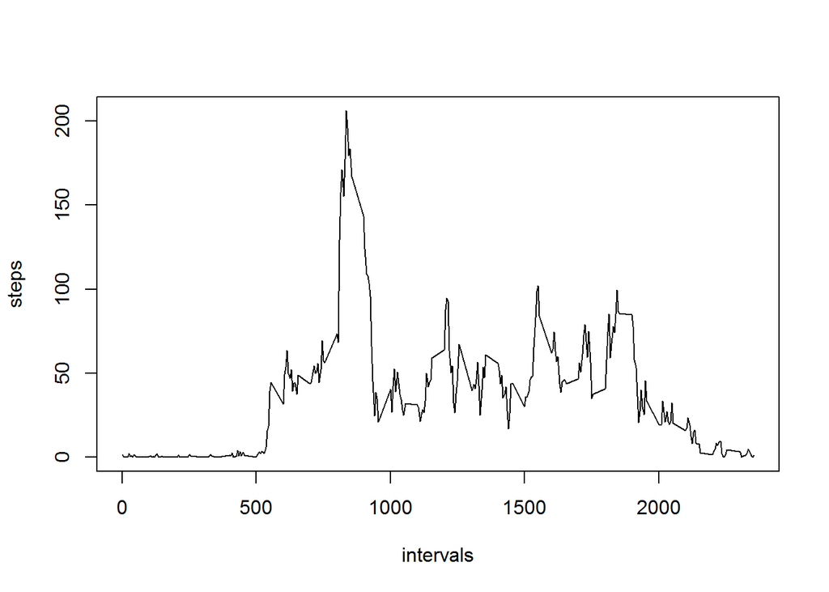

```r
by_interval<-group_by(Ractivity[!is.na(Ractivity$steps),],interval)
intervalsteps<-summarize(by_interval,AverageSteps=mean(steps))
plot(intervalsteps$interval,intervalsteps$AverageSteps,type="l",xlab="intervals",
     ylab="steps")
```

#### 2- Which 5-minute interval, on average across all the days in the dataset, contains the maximum number of steps?

```r
intervalsteps[max(intervalsteps$AverageSteps)==intervalsteps$AverageSteps,]
```

```
## Source: local data frame [1 x 2]
##
##   interval AverageSteps
## 1      835     206.1698
```

## Imputing missing values

### Note that there are a number of days/intervals where there are missing values (coded as NA). The presence of missing days may introduce bias into some calculations or summaries of the data.

#### 1- Calculate and report the total number of missing values in the dataset (i.e. the total number of rows with NAs)

```r
sum(is.na(Ractivity))
```

```
## [1] 2304
```

#### 2- Devise a strategy for filling in all of the missing values in the dataset.

#### The strategy does not need to be sophisticated. For example, you could use the mean/median for that day, or the mean for that 5-minute interval, etc.

###### In this question first of all Imputing takes by mean values base on Date Steps then on 5 min Intervals. Another imputing strategy is taking median of steps values first base on Dates and then by Intervals.

```r
#### Imputing by Average
# average by date
menactivity<- Ractivity;
mean_by_date<-group_by(Ractivity[!is.na(Ractivity$steps),],date)
mean_DateSteps<-summarize(mean_by_date,MeanStepsPerDay=mean(steps))
# average by interval
mean_by_interval<-group_by(Ractivity[!is.na(Ractivity$steps),],interval)
mean_IntervalSteps<-summarize(mean_by_interval,MeanStepsPerInterval=mean(steps))
for (i in 1:nrow(Ractivity)){
        if (is.na(Ractivity$steps[i])){
                if (sum(Ractivity$date[i]==mean_DateSteps$date)!=0){
                        menactivity$steps[i] <- mean_DateSteps$MeanStepsPerDay[(Ractivity$date[i]==mean_DateSteps$date)]
                        #### Imputing Strategy Base On Date Steps
                }else{
                        menactivity$steps[i] <- mean_IntervalSteps$MeanStepsPerInterval[(Ractivity$interval[i]==mean_IntervalSteps$interval)]
                        #### Imputing Strategy Base On 5 Min Intervals
                }
        }else{
                menactivity$steps[i] <-  Ractivity$steps[i]
        }
}
head(menactivity,10)
```

```
## Source: local data frame [10 x 3]
##
##        steps       date interval
## 1  1.7169811 2012-10-01        0
## 2  0.3396226 2012-10-01        5
## 3  0.1320755 2012-10-01       10
## 4  0.1509434 2012-10-01       15
## 5  0.0754717 2012-10-01       20
## 6  2.0943396 2012-10-01       25
## 7  0.5283019 2012-10-01       30
## 8  0.8679245 2012-10-01       35
## 9  0.0000000 2012-10-01       40
## 10 1.4716981 2012-10-01       45
```

```r
#### Imputing by median
# median by date
medactivity<- Ractivity;
median_by_date <- group_by(Ractivity[!is.na(Ractivity$steps),],date)
median_DateSteps <- summarize(median_by_date,MedianStepsPerDay=median(steps))
# median by interval
median_by_interval<-group_by(Ractivity[!is.na(Ractivity$steps),],interval)
median_IntervalSteps<-summarize(median_by_interval,MedianStepsPerInterval=median(steps))
for (i in 1:nrow(Ractivity)){
        if (is.na(Ractivity$steps[i])){
                if (sum(Ractivity$date[i]==median_DateSteps$date)!=0){
                        medactivity$steps[i] <- median_DateSteps$MedianStepsPerDay[(Ractivity$date[i]==median_DateSteps$date)]
                        #### Imputing Strategy Base On Date Steps
                }else{
                        medactivity$steps[i] <-median_IntervalSteps$MedianStepsPerInterval[(Ractivity$interval[i]==median_IntervalSteps$interval)]
                        #### Imputing Strategy Base On 5 Min Intervals
                }
        }else{
                medactivity$steps[i] <-  Ractivity$steps[i]
        }
}
head(medactivity,10)
```

```
## Source: local data frame [10 x 3]
##
##    steps       date interval
## 1      0 2012-10-01        0
## 2      0 2012-10-01        5
## 3      0 2012-10-01       10
## 4      0 2012-10-01       15
## 5      0 2012-10-01       20
## 6      0 2012-10-01       25
## 7      0 2012-10-01       30
## 8      0 2012-10-01       35
## 9      0 2012-10-01       40
## 10     0 2012-10-01       45
```

#### 3- Create a new dataset that is equal to the original dataset but with the missing data filled in.

```r
write.table(menactivity,file="menactivity.csv", row.name=F,col.names=T) #### Data Base on mean controlling Strategy
write.table(medactivity,file="medactivity.csv", row.name=F,col.names=T) #### Data Base on median controlling Strategy
```

#### Survey By Mean

```r
mean_by_date<-group_by(menactivity,date)
mean_total_steps<-summarize(mean_by_date, TotalStepsPerDay=sum(steps))
mean_by_interval<-group_by(menactivity[!is.na(menactivity$steps),],interval)
mean_intervalsteps<-summarize(mean_by_interval,AverageSteps=mean(steps))
```

#### Survey By Median

```r
median_by_date<-group_by(medactivity,date)
median_total_steps<-summarize(median_by_date, TotalStepsPerDay=sum(steps))
median_by_interval<-group_by(medactivity[!is.na(medactivity$steps),],interval)
median_intervalsteps<-summarize(median_by_interval,AverageSteps=mean(steps))
```

##### Histogram Plot

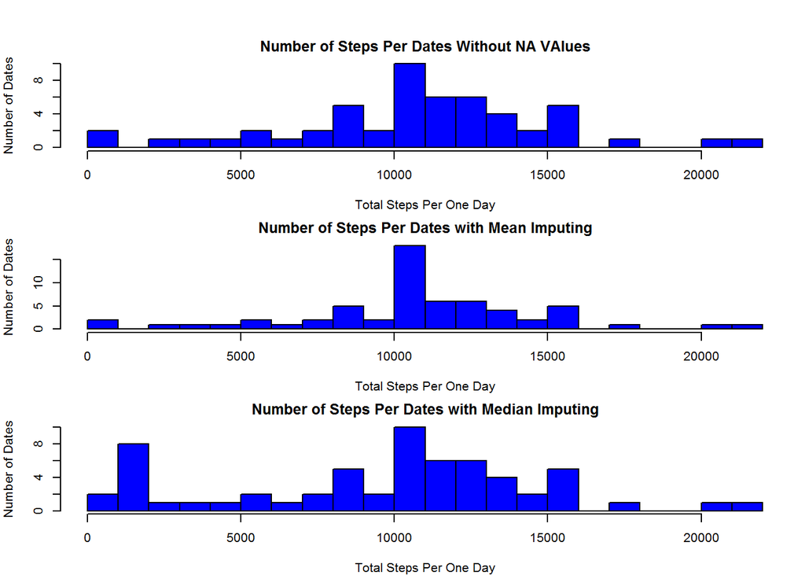

```r
par(mfrow=c(3,1),mar=c(4,4,2,1),oma=c(0,0,2,0))
with(Ractivity,{
        hist(total_steps$TotalStepsPerDay,30,col = "blue",
             xlab="Total Steps Per One Day",ylab="Number of Dates",
             main="Number of Steps Per Dates Without NA VAlues")
        hist(mean_total_steps$TotalStepsPerDay,30,col = "blue",
        xlab="Total Steps Per One Day",ylab="Number of Dates",
        main="Number of Steps Per Dates with Mean Imputing")
        hist(median_total_steps$TotalStepsPerDay,30,col = "blue",
        xlab="Total Steps Per One Day",ylab="Number of Dates",
        main="Number of Steps Per Dates with Median Imputing")
})
```

##### Time Series Plot

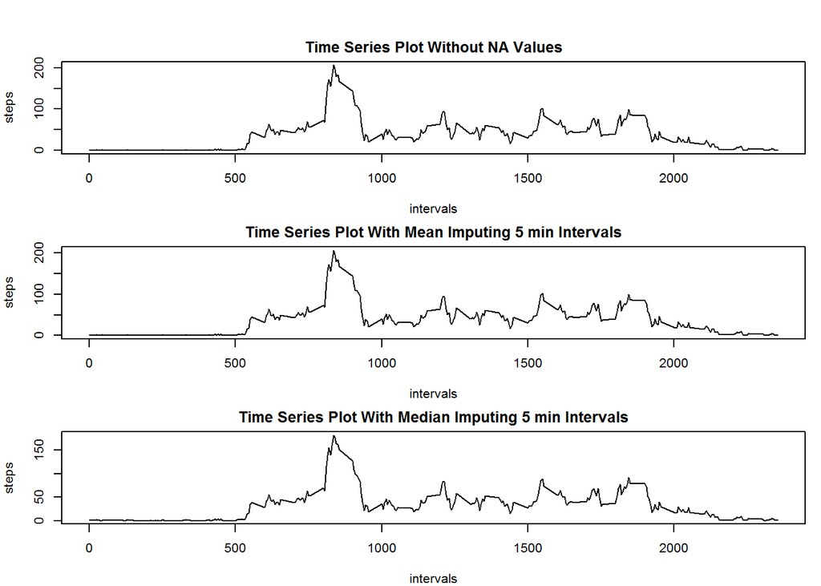

```r
par(mfrow=c(3,1),mar=c(4,4,2,1),oma=c(0,0,2,0))
with(Ractivity,{
        plot(intervalsteps$interval,intervalsteps$AverageSteps,type="l",
             main="Time Series Plot Without NA Values",
             xlab="intervals",ylab="steps")
        plot(mean_intervalsteps$interval,mean_intervalsteps$AverageSteps,type="l",
             main="Time Series Plot With Mean Imputing 5 min Intervals",
             xlab="intervals",ylab="steps")
        plot(median_intervalsteps$interval,median_intervalsteps$AverageSteps,type="l",
             xlab="intervals", ylab="steps",
             main="Time Series Plot With Median Imputing 5 min Intervals")
})
```

#### Do these values differ from the estimates from the first part of the assignment?

In Histogram Plot mean and median imputing cause non zero values in Not Assigned data. Mean and median imputing cause increase in similar steps of histogram plot.

#### What is the impact of imputing missing data on the estimates of the total daily number of steps?

Time series plot shows high similarity between imputed NA values and without NA values structure.

## Are there differences in activity patterns between weekdays and weekends?

## For this part the weekdays() function may be of some help here.

## Use the dataset with the filled-in missing values for this part.

#### 1- Create a new factor variable in the dataset with two levels – “weekday” and “weekend” indicating whether a given date is a weekday or weekend day.

```r
library(dplyr);library(lubridate)
weekend<-c("Sunday","Saturday")
week<-rep(0,nrow(menactivity))
for (i in 1:nrow(menactivity)){
        if (sum(weekdays(ymd(menactivity$date[i]))==weekend)!=0){
                week[i] <- "weekend"
        }else{
                week[i] <- "weekday"
        }
}
newactivity<-mutate(menactivity,weekdays=factor(week))
head(newactivity,6)
```

```
## Source: local data frame [6 x 4]
##
##       steps       date interval weekdays
## 1 1.7169811 2012-10-01        0  weekday
## 2 0.3396226 2012-10-01        5  weekday
## 3 0.1320755 2012-10-01       10  weekday
## 4 0.1509434 2012-10-01       15  weekday
## 5 0.0754717 2012-10-01       20  weekday
## 6 2.0943396 2012-10-01       25  weekday
```

#### 2- Make a panel plot containing a time series plot (i.e. type = “l”) of the 5-minute interval (x-axis) and the average number of steps taken, averaged across all weekday days or weekend days (y-axis).

#### See the README file in the GitHub repository to see an example of what this plot should look like using simulated data.

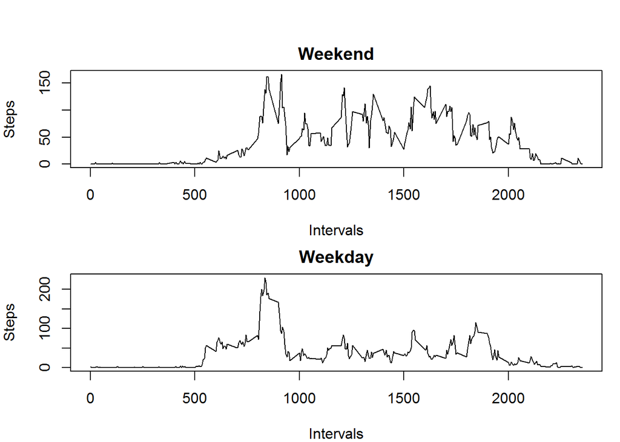

```r
weekendactivity<-newactivity[newactivity$weekdays=="weekend",]
weekdayactivity<-newactivity[newactivity$weekdays=="weekday",]

weekendgroup<-group_by(weekendactivity,interval)
WeekendMean<-summarize(weekendgroup,MeanPerInterval=mean(steps))

weekdaygroup<-group_by(weekdayactivity,interval)
WeekdayMean<-summarize(weekdaygroup,MeanPerInterval=mean(steps))

par(mfrow=c(2,1),mar=c(4,4,2,1),oma=c(0,0,2,0))
with(newactivity,{
        plot(WeekendMean$interval,WeekendMean$MeanPerInterval,type="l",
             xlab="Intervals",ylab="Steps",main="Weekend")
        plot(WeekdayMean$interval,WeekdayMean$MeanPerInterval,type="l",
             xlab="Intervals",ylab="Steps",main="Weekday")
})
```